# Graph Kernels as Preprocessing for Unsupervised Text Mining Methods

9/21/2020

## About Me

[figure not shown]

[figure not shown]

- B.S. Applied Mathematics (Shippensburg University of Pennsylvania).
- Teaching Assistant: Pre-Calc (Ship), Applied Calculus (Ship), Intro to Data Science, Statistical Learning, Data & Text Mining, and Scientific Computing.
- Other: I love cooking, I am a big basketball fan, I love hiking/backpacking.

## About Me

[figure not shown]

- 1 **Glorious** Publication, on Text Mining Social Media (Under Dr. Sanchez-Arias, more on the way).
- Internships: Industrial Engineering (Volvo Construction), Research Analyst (Security Start-Up), Data Scientist (IoT Start-Up)
- Career: later this semester I start my career as a data scientist at the Department of Defense!

## Introduction

My proposed thesis topic, *Graph Kernels as Preprocessing for Unsupervised Text Mining Methods*, will use modern techniques on familiar data to present some novel research. The goal is to use **graph kernels** in conjunction with unsupervised methods, and to study the pairing of these methods. The data sources, **NHSTA Crash Reports** and **social media discussion on health**, will be of interest to the university.

[figure not shown]

[figure not shown]

NHTSA SCI reports. Social Media: reddit

## Graph Kernels

A graph kernels is a kernel function that computes the inner product of two graphs. This allows for a **measure of similarity** between two graphs. Using this measure to compare **graph representations** of documents, provides a way to assess similarity of documents. With the measure we can also perform unsupervised methods (clustering).

Types:

- Random Walk Kernels
- Graphlet Kernels
- Tree-Based Kernels

## Graph Representations: Skip-Grams!

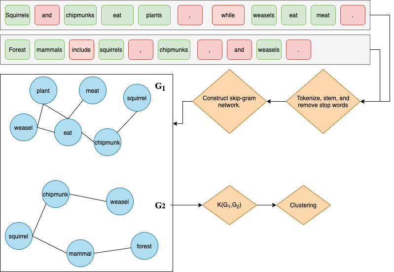

## Research Questions

1. How do differing styles of text affect graph kernel methods for text mining?
2. Which clustering methods work best with the kernel methods?
3. What modifications can be made to the graph representation to improve clustering results?

## Methods

1. Compare **graph kernel** text mining methods performance on differing types of text. In this case, NHSTA reports (lengthy documents) and social media comments/threads (short documents). Computation speed/feasibility? Accuracy or other success defining metrics?
2. Use the kernel function to **evaluate distance** within in the kernel function range, which will allow for **clustering methods** to be applied (hierarchical, DBSCAN, k-means, etc). Assess **performance** accross differing methods on the same data.
3. Can we edit the graph representations to improve performance? Edit window width of the skip-grams, edit weighting on edges, and more.

## Data Sources

Two very different data sources will be used. The NHTSA crash reports represent an example of a lengthy technical document, with a small number of samples (\(N<125\)). Comments and threads from social media (Twitter or reddit) represent short documents where language is often more casual, with far more samples available depending on the topic of discussion.

In addition, if time permits, a new data source may be considered to further emphasize differing performance accross documents. These data sources may include product reviews, fiction novels, news reports, etc.

## Deliverables

- Paper submitted for publication.
- Reproducible and open repository for others to build upon.
- data sets used in analysis provided in the open-source repository.

## Timeline

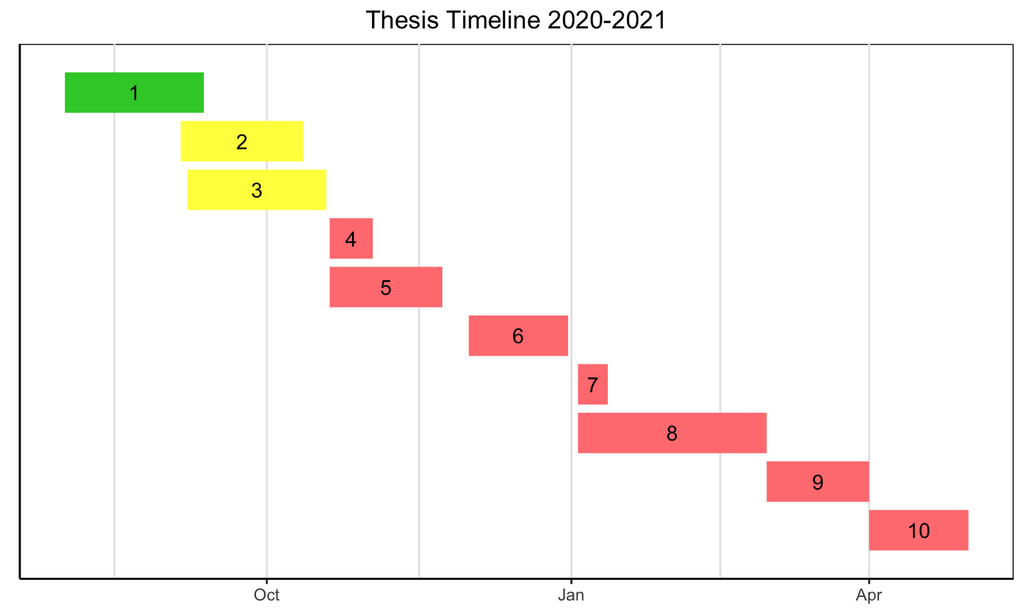

Schedule of Events

| Event | Name | Finish |
| --- | --- | --- |
| 1 | Literature Review | 2020-09-12 |
| 2 | Data Collection & Prep | 2020-10-12 |
| 3 | Exploratory Data Analysis | 2020-10-19 |
| 4 | Preliminary Analysis | 2020-11-02 |
| 5 | Writing and Editing for Publication | 2020-11-23 |
| 6 | Submit to Conference/Journal | 2020-12-31 |
| 7 | Additional Analysis | 2021-01-12 |
| 8 | Writing Draft Manuscript | 2021-03-01 |
| 9 | Final Manuscript | 2021-04-01 |
| 10 | Defense | 2021-05-01 |

## References

- Akioyamen, P., Nicklas, L. C., & Sanchez-Arias, R. (2020). A framework for intelligent navigation using latent dirichlet allocation on reddit posts about opiates. In Proceed- ings of the 2020 the 4th international conference on compute and data analysis (pp. 190–196).
- Cheng, W., Greaves, C., & Warren, M. (2006). From n-gram to skipgram to concgram. International journal of corpus linguistics, 11(4), 411–433.
- Csardi, G., Nepusz, T., et al. (2006). The igraph software package for complex network research. InterJournal, complex systems, 1695(5), 1–9.
- Kondor, R. I., & Lafferty, J. (2002). Diffusion kernels on graphs and other discrete struc- tures. In Proceedings of the 19th international conference on machine learning (Vol. 2002, pp. 315–22).
- Kriege, N. M., Johansson, F. D., & Morris, C. (2020). A survey on graph kernels. Applied Network Science, 5(1), 1–42.
- Nikolentzos, G., Meladianos, P., Rousseau, F., Stavrakas, Y., & Vazirgiannis, M. (2017). Shortest-path graph kernels for document similarity. In Proceedings of the 2017 con- ference on empirical methods in natural language processing (pp. 1890–1900).
- Silge, J., & Robinson, D. (2016). tidytext: Text mining and analysis using tidy data principles in r. Journal of Open Source Software, 1(3), 37.
- Sugiyama, M., Ghisu, M. E., Llinares-L ́opez, F., & Borgwardt, K. (2018). graphkernels: R and python packages for graph comparison. Bioinformatics, 34(3), 530–532.
- Vishwanathan, S. V. N., Schraudolph, N. N., Kondor, R., & Borgwardt, K. M. (2010). Graph kernels. The Journal of Machine Learning Research, 11, 1201–1242.
- Wickham, H., Averick, M., Bryan, J., Chang, W., McGowan, L. D., Fran ̧cois, R., . . . others (2019). Welcome to the tidyverse. Journal of Open Source Software, 4(43), 1686.